# Partial absorption in a core-shell dimer

[output not shown]

[output not shown]

[output not shown]

[output not shown]

[output not shown]

## Total cross-sections

We first retrieve the total cross-sections, as usual,

**Show output structure (click to open)**

```
                           group               name       otype dclass      dim
0                              /          Far-Field   H5I_GROUP
1                     /Far-Field        Wavelengths H5I_DATASET  FLOAT      101
2                     /Far-Field    fixed_incidence   H5I_GROUP
3     /Far-Field/fixed_incidence            Weights H5I_DATASET  FLOAT       38
4     /Far-Field/fixed_incidence            csAbs1X H5I_DATASET  FLOAT 101 x 39
5     /Far-Field/fixed_incidence            csAbs2Y H5I_DATASET  FLOAT 101 x 39
6     /Far-Field/fixed_incidence            csAbs3R H5I_DATASET  FLOAT 101 x 39
7     /Far-Field/fixed_incidence            csAbs4L H5I_DATASET  FLOAT 101 x 39
8     /Far-Field/fixed_incidence            csExt1X H5I_DATASET  FLOAT 101 x 39
9     /Far-Field/fixed_incidence            csExt2Y H5I_DATASET  FLOAT 101 x 39
10    /Far-Field/fixed_incidence            csExt3R H5I_DATASET  FLOAT 101 x 39
11    /Far-Field/fixed_incidence            csExt4L H5I_DATASET  FLOAT 101 x 39
12    /Far-Field/fixed_incidence            csSca1X H5I_DATASET  FLOAT 101 x 39
13    /Far-Field/fixed_incidence            csSca2Y H5I_DATASET  FLOAT 101 x 39
14    /Far-Field/fixed_incidence            csSca3R H5I_DATASET  FLOAT 101 x 39
15    /Far-Field/fixed_incidence            csSca4L H5I_DATASET  FLOAT 101 x 39
16                    /Far-Field       oa_incidence   H5I_GROUP
17       /Far-Field/oa_incidence            cdAbsOA H5I_DATASET  FLOAT  101 x 9
18       /Far-Field/oa_incidence            cdExtOA H5I_DATASET  FLOAT  101 x 9
19       /Far-Field/oa_incidence            cdScaOA H5I_DATASET  FLOAT  101 x 9
20       /Far-Field/oa_incidence            csAbsOA H5I_DATASET  FLOAT  101 x 9
21       /Far-Field/oa_incidence            csExtOA H5I_DATASET  FLOAT  101 x 9
22       /Far-Field/oa_incidence            csScaOA H5I_DATASET  FLOAT  101 x 9
23                    /Far-Field partial_absorption   H5I_GROUP
24 /Far-Field/partial_absorption csAbs1X_scat1coat0 H5I_DATASET  FLOAT 101 x 39
25 /Far-Field/partial_absorption csAbs1X_scat1coat1 H5I_DATASET  FLOAT 101 x 39
26 /Far-Field/partial_absorption csAbs1X_scat2coat0 H5I_DATASET  FLOAT 101 x 39
27 /Far-Field/partial_absorption csAbs1X_scat2coat1 H5I_DATASET  FLOAT 101 x 39
28 /Far-Field/partial_absorption csAbs2Y_scat1coat0 H5I_DATASET  FLOAT 101 x 39
29 /Far-Field/partial_absorption csAbs2Y_scat1coat1 H5I_DATASET  FLOAT 101 x 39
30 /Far-Field/partial_absorption csAbs2Y_scat2coat0 H5I_DATASET  FLOAT 101 x 39
31 /Far-Field/partial_absorption csAbs2Y_scat2coat1 H5I_DATASET  FLOAT 101 x 39
32 /Far-Field/partial_absorption csAbs3R_scat1coat0 H5I_DATASET  FLOAT 101 x 39
33 /Far-Field/partial_absorption csAbs3R_scat1coat1 H5I_DATASET  FLOAT 101 x 39
34 /Far-Field/partial_absorption csAbs3R_scat2coat0 H5I_DATASET  FLOAT 101 x 39
35 /Far-Field/partial_absorption csAbs3R_scat2coat1 H5I_DATASET  FLOAT 101 x 39
36 /Far-Field/partial_absorption csAbs4L_scat1coat0 H5I_DATASET  FLOAT 101 x 39
37 /Far-Field/partial_absorption csAbs4L_scat1coat1 H5I_DATASET  FLOAT 101 x 39
38 /Far-Field/partial_absorption csAbs4L_scat2coat0 H5I_DATASET  FLOAT 101 x 39
39 /Far-Field/partial_absorption csAbs4L_scat2coat1 H5I_DATASET  FLOAT 101 x 39
```

```
'data.frame':   606 obs. of  6 variables:
 $ wavelength: num  300 305 310 315 320 325 330 335 340 345 ...
 $ crosstype : chr  "Abs" "Abs" "Abs" "Abs" ...
 $ variable  : Factor w/ 9 levels "total","I1","I2",..: 1 1 1 1 1 1 1 1 1 1 ...
 $ dichroism : num  -1.04e-11 -1.13e-11 -9.39e-12 -1.07e-11 -9.81e-12 ...
 $ average   : num  9862 9855 9844 9832 9821 ...
 $ case      : chr  "Au@Au" "Au@Au" "Au@Au" "Au@Au" ...
```

## Per-layer absorption

Additional files/fields in the form `csAbs4L_scat00{i}coat{i}` are created for each layered sphere, containing partial absorption cross-sections for particle ${i}$, up to layer ${j}$, with columns for each angle of incidence and the weighted average,

To get the per-layer absorption we need to take the difference between successive coats.

```
Rows: 1,212
Columns: 6
$ scatterer  <int> 1, 1, 1, 1, 1, 1, 1, 1, 1, 1, 1, 1, 1, 1, 1, 1, 1, 1, 1, 1,…
$ wavelength <dbl> 300, 300, 300, 305, 305, 305, 310, 310, 310, 315, 315, 315,…
$ region     <chr> "total_avg", "shell_avg", "core_avg", "total_avg", "shell_a…
$ value      <dbl> 4931.2215, 586.2634, 4344.9581, 4927.3451, 581.5501, 4345.7…
$ case       <chr> "Au@Au", "Au@Au", "Au@Au", "Au@Au", "Au@Au", "Au@Au", "Au@A…
$ crosstype  <chr> "Abs", "Abs", "Abs", "Abs", "Abs", "Abs", "Abs", "Abs", "Ab…
```

In this plot the total absorption and per-particle absorption for the core-shell coincide.

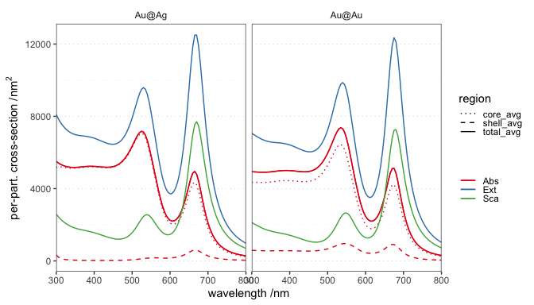

The absorption in the Ag layer is maximum at the plasmon resonance of the dimer, the position of which is largely dictated by the gold cores.

*Last run: 05 October, 2021*